# Week 1 report

In this notebook I am computing the functions that are mentioned in the *Week 1 Report*.

## 1.1. First Definitions

### Function 1. Which of these variables are compositional?

This function takes a set of variables in a list (each of them matrices or vectors) and returns a vector of zeros and ones. The component in position *i*, associated to the *i* position of the input vector, should be one if that matrix add up to a constant value and zero otherwise. This could be adjusted to add up approximately to a constant because of the roundings in transformed variables and so.

```r
which_coda=function(l,eps){ # l = list of variables, # eps = allowed error
  result = numeric()
  for (i in l){
    if (is.integer(dim(i)[2])==TRUE){
      range = max(rowSums(i))-min(rowSums(i))
      if (range<=eps){result <- c(result, 1)}
      else{result <- c(result, 0)}
    }
    else{result <- c(result, 0)}
  }
  return(result)
}
```

We are doing a tiny example for a simple vector which cannot be compositional data by definition, a matrix which apparently is a compositional vector and a matrix that is not.

```r
m1 = matrix(c(0.25,0.249999,0.2,0.2))
m1 <- cbind(m1, c(0.3, 0.3, 0.3, 0.35))
m1 <- cbind(m1, c(0.45, 0.45, 0.5, 0.45)) # definig the comp matrix

m2 = matrix(c(0.25,0.249999,0.2,0.2))
m2 <- cbind(m2, c(0.3, 0.9, 0.3, 0.35))
m2 <- cbind(m2, c(0.45, 0.45, 0.5, 0.65)) # definig the non comp matrix

v1 = c(1,2,2,1) # simple vector
lex = list(v1,m1,m2)
```

Vector:

```r
v1
```

```
## [1] 1 2 2 1
```

Compositional Matrix:

```r
m1
```

```
##          [,1] [,2] [,3]
## [1,] 0.250000 0.30 0.45
## [2,] 0.249999 0.30 0.45
## [3,] 0.200000 0.30 0.50
## [4,] 0.200000 0.35 0.45
```

Non Compositional Matrix:

```r
m2
```

```
##          [,1] [,2] [,3]
## [1,] 0.250000 0.30 0.45
## [2,] 0.249999 0.90 0.45
## [3,] 0.200000 0.30 0.50
## [4,] 0.200000 0.35 0.65
```

Results if no deviation for the sum of the components is allowed:

```r
which_coda(lex,0)
```

```
## [1] 0 0 0
```

Results if a tiny (0.001) deviation for the sum of the components is allowed:

```r
which_coda(lex,0.001)
```

```
## [1] 0 1 0
```

### Function 2. Closed form operator.

This function returns the closed form of a given compositional vector (given as a matrix).

```r
C=function(x, k){ # x the matrix of the variable, k the constant (=1 if missing)
  if (missing(k)){
    newx <- (x)/rowSums(x)
    return(newx)
  }
  else{
    newx <- (k*x)/rowSums(x)
    return(newx)
  }
}
```

An example with the previously defined “m2” FOR $k=1$:

```r
C(m2)
```

```
##           [,1]      [,2]      [,3]
## [1,] 0.2500000 0.3000000 0.4500000
## [2,] 0.1562495 0.5625004 0.2812502
## [3,] 0.2000000 0.3000000 0.5000000
## [4,] 0.1666667 0.2916667 0.5416667
```

An example with the previously defined “m2” FOR $k=100$:

```r
C(m2,100)
```

```
##          [,1]     [,2]     [,3]
## [1,] 25.00000 30.00000 45.00000
## [2,] 15.62495 56.25004 28.12502
## [3,] 20.00000 30.00000 50.00000
## [4,] 16.66667 29.16667 54.16667
```

### Function 3. Naive Ternary plot (from scratch).

Here is the code for plotting ternary diagrams. Its input is a matrix with the compositional data and its output the aforementioned plot. Of course, it is very naive -yet-.

```r
ternary=function(mat){ # depends only in the data matrix containing the compositional datA
  x = mat[1,][1]
  y = mat[1,][2]
  z = mat[1,][3]
  p=c(0.5*(2*y+z)/(x+y+z), sqrt(3/2)*(z/(x+y+z)))
  plot(p[1],p[2],xlim=c(0,1),ylim=c(0,1), pch=20,xlab=" ",ylab=" ", cex=0.5)
  if (nrow(mat)>1){
    for (i in 2:nrow(mat)){
    x = mat[i,][1]
    y = mat[i,][2]
    z = mat[i,][3]
    p=c(0.5*(2*y+z)/(x+y+z), sqrt(3/2)*(z/(x+y+z)))
    points(p[1],p[2],pch=20, cex=0.5)
    }
  }
  segments(0,0,1,0)
  segments(0.5,sqrt(3/4),0,0)
  segments(0.5,sqrt(3/4),1,0)
}
```

And here, one example with out 4 row “m2” matrix:

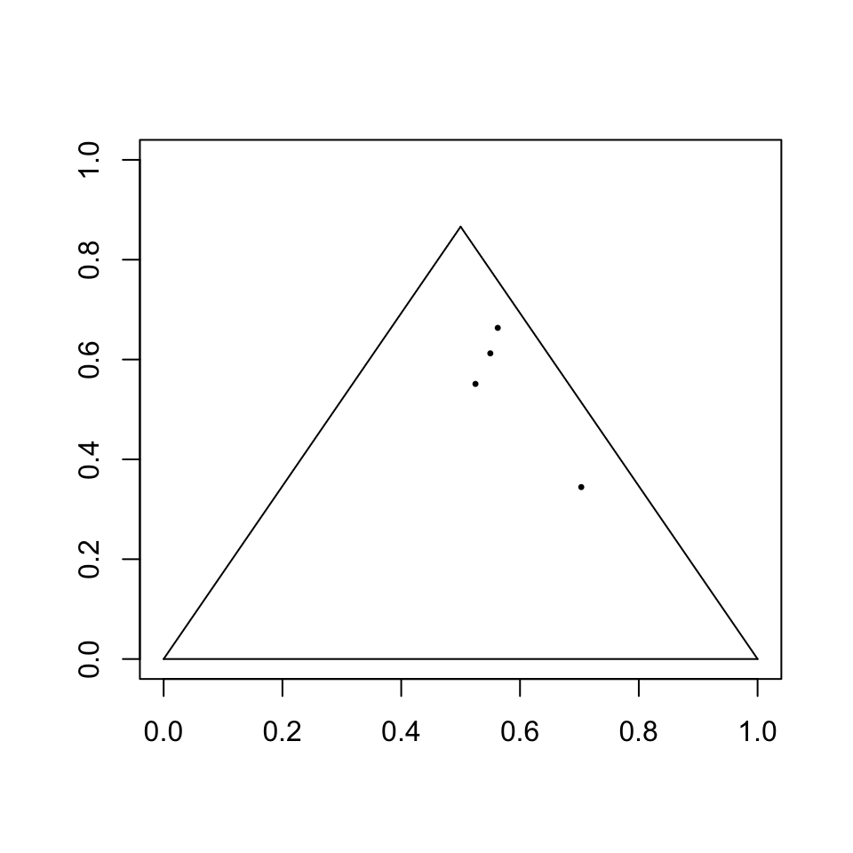

```r
ternary(m2)
```

## 1.2.1 The Aitchison Geometry (Operations)

### Function 4. The perturbation.

The perturbation in the Aitchison geometry is defined as $\mathbf{x}\oplus\mathbf{p} = \mathcal{C}[x_1p_1,...,x_Dp_D]$:

```r
pt = function (x,y){ # I prefer to keep an easy name for this kind of functions, x and y are matrix 1xD
  return(C(x*y))
}
```

We define $x_1$ and $x_2$ and use the perturbation operation.

```r
x1 = t(matrix(c(0.3,2,1,3)))
x2 = t(matrix(c(3,  1,2,4)))

pt(x1,x2)
```

```
##            [,1]      [,2]      [,3]      [,4]
## [1,] 0.05325444 0.1183432 0.1183432 0.7100592
```

We can see that $x_1 \oplus x_2$ lies in the simplex.

```r
sum(pt(x1,x2))
```

```
## [1] 1
```

### Function 5. The powering.

The powering function is defined by $\lambda \odot \mathbf{x} = \mathcal{C}[x_1^\lambda,...,x_D^\lambda]$.

```r
pw=function(l,x){ # x the vector (matrix 1xD) and l stands for the scalar
  return(C(x**l))
}
```

As an example, $2\odot x_1$, which should coincide with $x_1\oplus x_1$:

```r
pw(2,x1) # powering
```

```
##             [,1]      [,2]       [,3]      [,4]
## [1,] 0.006387509 0.2838893 0.07097232 0.6387509
```

```r
pt(x1,x1) # perturbation
```

```
##             [,1]      [,2]       [,3]      [,4]
## [1,] 0.006387509 0.2838893 0.07097232 0.6387509
```

### Function 6. The Aitchison inner product.

The inner product of this geometry is defined as: $\langle \mathbf{x}, \mathbf{y} \rangle_A = \dfrac{1}{D} \sum_{i=1}^{D-1}\sum_{j=i+1}^{D} \ln\dfrac{x_i}{x_j}\ln\dfrac{y_i}{y_j}$.

```r
inner = function(x,y){ # x, y are Dx1 matrices
  result = 0
  D = ncol(x)
  for (i in (1:(D-1))){
    result <- result + sum(log(x[i]/x[(i+1):D])*(log(y[i]/y[(i+1):D])))
  }
  return((1/D)*result)
}
```

Thus, $\langle x_1,x_2 \rangle=-0.26672$

```r
inner(x1,x2)
```

```
## [1] -0.2667037
```

### Function 7. The Aitchison distance.

The distance is defined as $d_A(\mathbf{x},\mathbf{y}) = \left(\dfrac{1}{D} \sum_{i=1}^{D-1}\sum_{j=i+1}^{D} \left(\ln\dfrac{x_i}{x_j}-\ln\dfrac{y_i}{y_j}\right)^2\right)^{1/2}$

```r
dist = function(x,y){ # x,y 1xD matrices
  result = 0
  D = ncol(x)
  for (i in (1:(D-1))){
    result <- result + sum((log(x[i]/x[(i+1):D])-(log(y[i]/y[(i+1):D])))**2)
  }
  return(((1/D)*result)**(1/2))
}
```

As any distance, $d_A(x_1,x_1)$ should be equal to 0 and positive otherwise:

```r
dist(x1,x1)
```

```
## [1] 0
```

```r
dist(x1,x2)
```

```
## [1] 2.1606
```

## 1.2.2 The Aitchison Geometry (Transformations)

### Function 8. The alr transfomration.

The alr transformation is given by: $\mathrm{alr}(\mathbf{x})=(\ln(x_1/x_D),...,\ln(x_{D-1}/x_D))$

```r
alr = function(x,i){   # x is a 1xD matrix, i an integer in (1,D): the "reference" element
  if (missing(i)){     # if i is not given, the last element is used
    return(log(x/x[length(x)]))
  }
  else{
    return(log(x/x[i]))
  }
}
```

For example, the transformation for $x_1$:

```r
alr(x1)
```

```
##           [,1]       [,2]      [,3] [,4]
## [1,] -2.302585 -0.4054651 -1.098612    0
```

### Function 9. The ilr transformation.

The ilr transformation is given by:

$\mathrm{ilr}(\mathbf{x})=\mathbf{V}^T_D\ln(\mathbf{x}):=x^*$

```r
ilr = function(x){ # x matrix 1xD as always
  V3 = matrix(c(sqrt(2/3),-sqrt(1/6),-sqrt(1/6)))
  V3 <- cbind(V3, c(0,sqrt(1/2),-sqrt(1/2))) # defining V3
  return(t(V3)%*%x)
}
```

```r
x3=c(0.4,0.2,0.4)
ilr(x3)
```

```
##             [,1]
## [1,]  0.08164966
## [2,] -0.14142136
```

### Function 10. The ilr inverse.

For this, the exponential of a matrix is needed. I will compute a naive Taylor-series based one (in order to avoid using external packages for the moment):

```r
expm = function(M, iter){ # matrix and number of iterations (the more the better)
  if (missing(iter)){     # if i is not given, the last element is used
    iter=100
  }
  res=diag(length(M[1,]))
  power=M
  for (i in 1:iter){
    res = res + power/factorial(i)
    power = power%*%M
  }
  return(res)
}
```

It works quite well!

```r
test1 <- t(matrix(c(4, 2, 0,1, 4, 1,1, 1, 4), 3, 3))
expm(test1,100)
```

```
##          [,1]     [,2]      [,3]
## [1,] 147.8666 183.7651  71.79703
## [2,] 127.7811 183.7651  91.88257
## [3,] 127.7811 163.6796 111.96811
```

Of course, this was not needed. I did not realise the dimensions.

Now, the inverse ilr (only for the D=3 case): $x=\mathrm{ilr}^{-1}(\mathbf{x}^*) = \mathcal{C}(\exp(\mathbf{V}_D x^*)$

```r
inverseilr=function(x){ # x is x*, vec of coordinates
  V3 = matrix(c(sqrt(2/3),-sqrt(1/6),-sqrt(1/6)))
  V3 <- cbind(V3, c(0,sqrt(1/2),-sqrt(1/2))) # defining V3
  return(C(t((exp(V3%*%x)))))
}
```

Testing the new function for $x_3$, we should have $\mathrm{ilr}^{-1}(\mathrm{ilr(\mathbf{x})})=\mathbf{x}$. It is not the case, but “almost”. **Why?**

```r
x3
```

```
## [1] 0.4 0.2 0.4
```

```r
inverseilr(ilr(x3))
```

```
##           [,1]      [,2]      [,3]
## [1,] 0.3547696 0.2904608 0.3547696
```